# Neural Network Example

Kachun Huang

2025-03-03

# Neural Network Example

## Import Libraries

```r
library(neuralnet)
library(MASS)
library(tidyverse)
library(leaps)
library(car)
library(caret)
library(dplyr)
library(lmtest)
```

## Import Dataset

The banknote.csv data (see attached) were extracted from images that were taken from genuine and forged banknote-like specimens. Yes, this is a Catch Me if You Can story. For digitization, an industrial camera usually used for print inspection was used. The final images have 400 x 400 pixels. (*3D would be called the voxels) Wavelet Transform tool were used to extract features from images.

There are 1,372 banknotes, and 5 variables:

1. variance of Wavelet Transformed image (continuous)
2. skewness of Wavelet Transformed image (continuous)
3. curtosis of Wavelet Transformed image (continuous)
4. entropy of image (continuous)
5. class (binary) – this is the response variable of interest, 1 (forged) or 0 (genuine)

```r
bank <- read.table("/Users/thomashuang/Downloads/banknote.csv",sep=",",header = TRUE)
head(bank)
```

|  | variance | skewness | curtosis | entropy | class |
| --- | --- | --- | --- | --- | --- |
| 1 | 3.62160 | 8.6661 | -2.8073 | -0.44699 | 1 |
| 2 | 4.54590 | 8.1674 | -2.4586 | -1.46210 | 1 |
| 3 | 3.86600 | -2.6383 | 1.9242 | 0.10645 | 1 |
| 4 | 3.45660 | 9.5228 | -4.0112 | -3.59440 | 1 |
| 5 | 0.32924 | -4.4552 | 4.5718 | -0.98880 | 1 |
| 6 | 4.36840 | 9.6718 | -3.9606 | -3.16250 | 1 |

```r
str(bank)
```

```
## 'data.frame':    1372 obs. of  5 variables:
##  $ variance: num  3.622 4.546 3.866 3.457 0.329 ...
##  $ skewness: num  8.67 8.17 -2.64 9.52 -4.46 ...
##  $ curtosis: num  -2.81 -2.46 1.92 -4.01 4.57 ...
##  $ entropy : num  -0.447 -1.462 0.106 -3.594 -0.989 ...
##  $ class   : int  1 1 1 1 1 1 1 1 1 1 ...
```

## Data Pre-Processing

### Remove Missing Values

```r
bank <- na.omit(bank)
str(bank)
```

```
## 'data.frame':    1372 obs. of  5 variables:
##  $ variance: num  3.622 4.546 3.866 3.457 0.329 ...
##  $ skewness: num  8.67 8.17 -2.64 9.52 -4.46 ...
##  $ curtosis: num  -2.81 -2.46 1.92 -4.01 4.57 ...
##  $ entropy : num  -0.447 -1.462 0.106 -3.594 -0.989 ...
##  $ class   : int  1 1 1 1 1 1 1 1 1 1 ...
```

None of the observation have missing values.

### Factorize response

```r
bank$class <- factor(bank$class)
```

## Data Splitting

```r
set.seed(123)
training.samples <- bank$class %>% createDataPartition(p=0.75, list=FALSE)
train.data <- bank[training.samples,]
test.data <- bank[-training.samples,]
```

## Perceptron Model with No Hidden Layers

### with SSE Loss function

```r
p_model_sse <- neuralnet(
  class ~.,
  train.data,
  hidden = 0,
  err.fct = "sse",
  linear.output = FALSE,
  act.fct = "logistic"
  )
```

#### Plot model

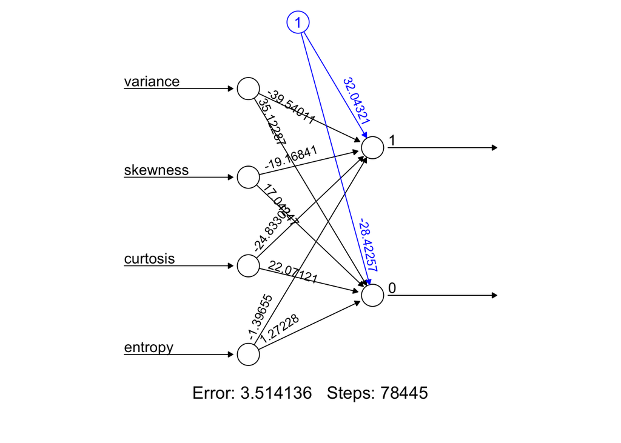

```r
plot(p_model_sse, rep="best")
```

#### Predict on Test Data

```r
pred_sse <- predict(p_model_sse, test.data)
pred_sse_class <- ifelse(pred_sse[,2] > 0.5,1,0)
```

#### Confusion Matrix

```r
confusionMatrix(factor(pred_sse_class), factor(test.data$class))
```

```
## Confusion Matrix and Statistics
##
##           Reference
## Prediction   0   1
##          0 148   0
##          1   4 190
##
##                Accuracy : 0.9883
##                  95% CI : (0.9703, 0.9968)
##     No Information Rate : 0.5556
##     P-Value [Acc > NIR] : <2e-16
##
##                   Kappa : 0.9763
##
##  Mcnemar's Test P-Value : 0.1336
##
##             Sensitivity : 0.9737
##             Specificity : 1.0000
##          Pos Pred Value : 1.0000
##          Neg Pred Value : 0.9794
##              Prevalence : 0.4444
##          Detection Rate : 0.4327
##    Detection Prevalence : 0.4327
##       Balanced Accuracy : 0.9868
##
##        'Positive' Class : 0
##
```

#### Sensitivity

$Sensitivity= P(\text{true positive}|\text{correct}) = \frac{TP}{TP+FN}$

```r
148 / (148+4)
```

```
## [1] 0.9736842
```

#### Specificity

$Specificity= P(\text{true negative}|\text{correct})=\frac{TN}{TN+FP}$

```r
190/(190+0)
```

```
## [1] 1
```

#### Overall Accuracy

$P(\text{Predicted Correctly}) = \frac{TP+TN}{TP+TN+FP+FN}$

```r
(148+190)/(148+190+4+0)
```

```
## [1] 0.9883041
```

### with CE Loss function

```r
p_model_ce <- neuralnet(
  class ~.,
  train.data,
  hidden = 0,
  err.fct = "ce",
  linear.output = FALSE,
  act.fct = "logistic"
  )
```

#### Plot model

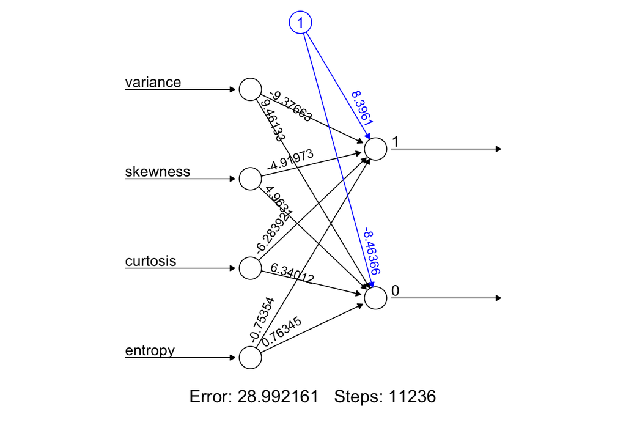

```r
plot(p_model_ce, rep="best")
```

#### Predict on Test Data

```r
pred_ce <- predict(p_model_ce, test.data)
pred_ce_class <- ifelse(pred_ce[,2] > 0.5,1,0)
```

#### Confusion Matrix

```r
confusionMatrix(factor(pred_ce_class), factor(test.data$class))
```

```
## Confusion Matrix and Statistics
##
##           Reference
## Prediction   0   1
##          0 148   1
##          1   4 189
##
##                Accuracy : 0.9854
##                  95% CI : (0.9662, 0.9952)
##     No Information Rate : 0.5556
##     P-Value [Acc > NIR] : <2e-16
##
##                   Kappa : 0.9703
##
##  Mcnemar's Test P-Value : 0.3711
##
##             Sensitivity : 0.9737
##             Specificity : 0.9947
##          Pos Pred Value : 0.9933
##          Neg Pred Value : 0.9793
##              Prevalence : 0.4444
##          Detection Rate : 0.4327
##    Detection Prevalence : 0.4357
##       Balanced Accuracy : 0.9842
##
##        'Positive' Class : 0
##
```

#### Sensitivity

$Sensitivity= P(\text{true positive}|\text{correct}) = \frac{TP}{TP+FN}$

```r
148/(148+4)
```

```
## [1] 0.9736842
```

#### Specificity

$Specificity= P(\text{true negative}|\text{correct})=\frac{TN}{TN+FP}$

```r
189 / (1+189)
```

```
## [1] 0.9947368
```

#### Overall Accuracy

$P(\text{Predicted Correctly}) = \frac{TP+TN}{TP+TN+FP+FN}$

```r
(148+189)/(148+1+4+189)
```

```
## [1] 0.9853801
```

## Logistic Regression

### Fit model

```r
logit_model <- glm(class ~ variance + skewness + curtosis + entropy,
                   data = train.data,
                   family = "binomial")
summary(logit_model)
```

[output not shown]

#### Predict on Test Data

```r
pred_logit <- predict(logit_model, test.data)
pred_logit_class <- ifelse(pred_logit > 0.5, 1,0)
```

#### Confusion Matrix

```r
confusionMatrix(factor(pred_logit_class),factor(test.data$class))
```

```
## Confusion Matrix and Statistics
##
##           Reference
## Prediction   0   1
##          0 148   1
##          1   4 189
##
##                Accuracy : 0.9854
##                  95% CI : (0.9662, 0.9952)
##     No Information Rate : 0.5556
##     P-Value [Acc > NIR] : <2e-16
##
##                   Kappa : 0.9703
##
##  Mcnemar's Test P-Value : 0.3711
##
##             Sensitivity : 0.9737
##             Specificity : 0.9947
##          Pos Pred Value : 0.9933
##          Neg Pred Value : 0.9793
##              Prevalence : 0.4444
##          Detection Rate : 0.4327
##    Detection Prevalence : 0.4357
##       Balanced Accuracy : 0.9842
##
##        'Positive' Class : 0
##
```

#### Sensitivity

$Sensitivity= P(\text{true positive}|\text{correct}) = \frac{TP}{TP+FN}$

```r
148/(148+4)
```

```
## [1] 0.9736842
```

#### Specificity

$Specificity= P(\text{true negative}|\text{correct})=\frac{TN}{TN+FP}$

```r
189 / (1+189)
```

```
## [1] 0.9947368
```

#### Overall Accuracy

$P(\text{Predicted Correctly}) = \frac{TP+TN}{TP+TN+FP+FN}$

```r
(148+189)/(148+189+4+1)
```

```
## [1] 0.9853801
```

## Perceptron Model with 1 Hidden Layers and 3 neurons

### with SSE Loss function

```r
p_model_layer_sse <- neuralnet(
  class ~.,
  train.data,
  hidden = 3,
  err.fct = "sse",
  linear.output = FALSE,
  act.fct = "logistic"
  )
```

#### Plot model

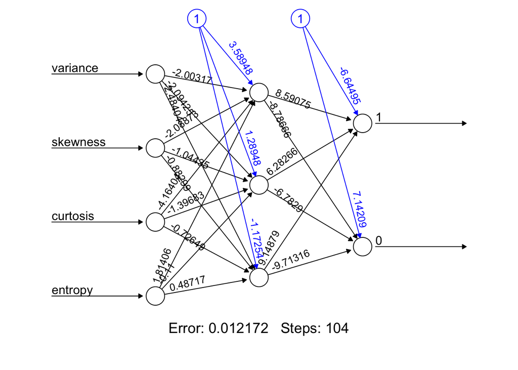

```r
plot(p_model_layer_sse, rep="best")
```

#### Predict on Test Data

```r
pred_layer_sse <- predict(p_model_layer_sse, test.data)
pred_layer_sse_class <- ifelse(pred_layer_sse[,2] > 0.5,1,0)
```

#### Confusion Matrix

```r
confusionMatrix(factor(pred_layer_sse_class), factor(test.data$class))
```

```
## Confusion Matrix and Statistics
##
##           Reference
## Prediction   0   1
##          0 152   0
##          1   0 190
##
##                Accuracy : 1
##                  95% CI : (0.9893, 1)
##     No Information Rate : 0.5556
##     P-Value [Acc > NIR] : < 2.2e-16
##
##                   Kappa : 1
##
##  Mcnemar's Test P-Value : NA
##
##             Sensitivity : 1.0000
##             Specificity : 1.0000
##          Pos Pred Value : 1.0000
##          Neg Pred Value : 1.0000
##              Prevalence : 0.4444
##          Detection Rate : 0.4444
##    Detection Prevalence : 0.4444
##       Balanced Accuracy : 1.0000
##
##        'Positive' Class : 0
##
```

#### Sensitivity

$Sensitivity= P(\text{true positive}|\text{correct}) = \frac{TP}{TP+FN}$

```r
152/(152+0)
```

```
## [1] 1
```

#### Specificity

$Specificity= P(\text{true negative}|\text{correct})=\frac{TN}{TN+FP}$

```r
190 / (0+190)
```

```
## [1] 1
```

#### Overall Accuracy

$P(\text{Predicted Correctly}) = \frac{TP+TN}{TP+TN+FP+FN}$

```r
(152+190)/(152+190+0+0)
```

```
## [1] 1
```

### with CE Loss function

```r
p_model_layer_ce <- neuralnet(
  class ~.,
  train.data,
  hidden = 3,
  err.fct = "ce",
  linear.output = FALSE,
  act.fct = "logistic"
  )
```

#### Plot model

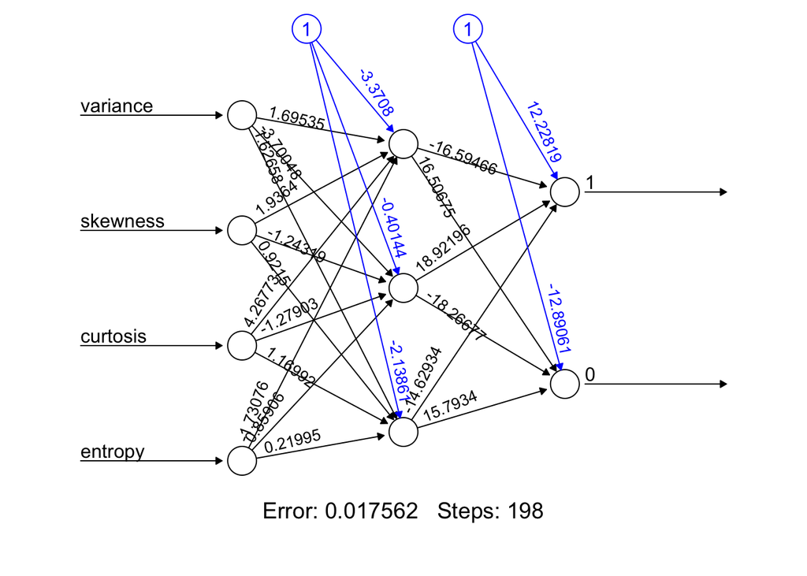

```r
plot(p_model_layer_ce, rep="best")
```

#### Predict on Test Data

```r
pred_layer_ce <- predict(p_model_layer_ce, test.data)
pred_layer_ce_class <- ifelse(pred_layer_ce[,2] > 0.5,1,0)
```

#### Confusion Matrix

```r
confusionMatrix(factor(pred_layer_ce_class), factor(test.data$class))
```

```
## Confusion Matrix and Statistics
##
##           Reference
## Prediction   0   1
##          0 152   0
##          1   0 190
##
##                Accuracy : 1
##                  95% CI : (0.9893, 1)
##     No Information Rate : 0.5556
##     P-Value [Acc > NIR] : < 2.2e-16
##
##                   Kappa : 1
##
##  Mcnemar's Test P-Value : NA
##
##             Sensitivity : 1.0000
##             Specificity : 1.0000
##          Pos Pred Value : 1.0000
##          Neg Pred Value : 1.0000
##              Prevalence : 0.4444
##          Detection Rate : 0.4444
##    Detection Prevalence : 0.4444
##       Balanced Accuracy : 1.0000
##
##        'Positive' Class : 0
##
```

#### Sensitivity

$Sensitivity= P(\text{true positive}|\text{correct}) = \frac{TP}{TP+FN}$

```r
152/(152+0)
```

```
## [1] 1
```

#### Specificity

$Specificity= P(\text{true negative}|\text{correct})=\frac{TN}{TN+FP}$

```r
190 / (0+190)
```

```
## [1] 1
```

#### Overall Accuracy

$P(\text{Predicted Correctly}) = \frac{TP+TN}{TP+TN+FP+FN}$

```r
(152+190)/(152+190+0+0)
```

```
## [1] 1
```